# Exponential Distribution

# Simulation Exercise

## Synopsis

In this project you will investigate the exponential distribution in R and compare it with the Central Limit Theorem. The exponential distribution can be simulated in R with rexp(n, lambda) where lambda is the rate parameter. The mean of exponential distribution is 1/lambda and the standard deviation is also 1/lambda. Set lambda = 0.2 for all of the simulations. You will investigate the distribution of averages of 40 exponentials. Note that you will need to do a thousand simulations.

Illustrate via simulation and associated explanatory text the properties of the distribution of the mean of 40 exponentials. You should

1.Show the sample mean and compare it to the theoretical mean of the distribution. 2.Show how variable the sample is (via variance) and compare it to the theoretical variance of the distribution. 3.Show that the distribution is approximately normal.

## Exponential Distribution

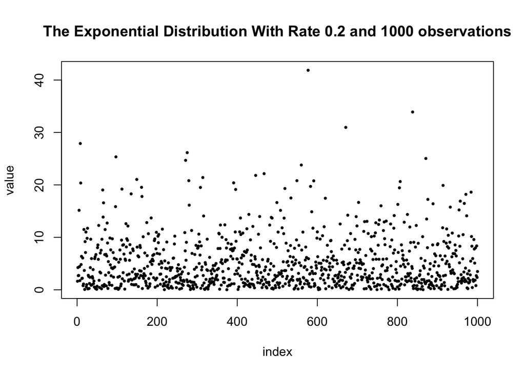

```r
set.seed(2017)
lamb <- 0.2
n <- 40
sim <- 1000

#Have a look a the distribution
plot(rexp(sim, lamb), pch=20, cex=0.6, main="The Exponential Distribution With Rate 0.2 and 1000 observations", xlab = "index", ylab = "value")
```

Lets plot the histogram of means of 1000 simulations of exponential distribution

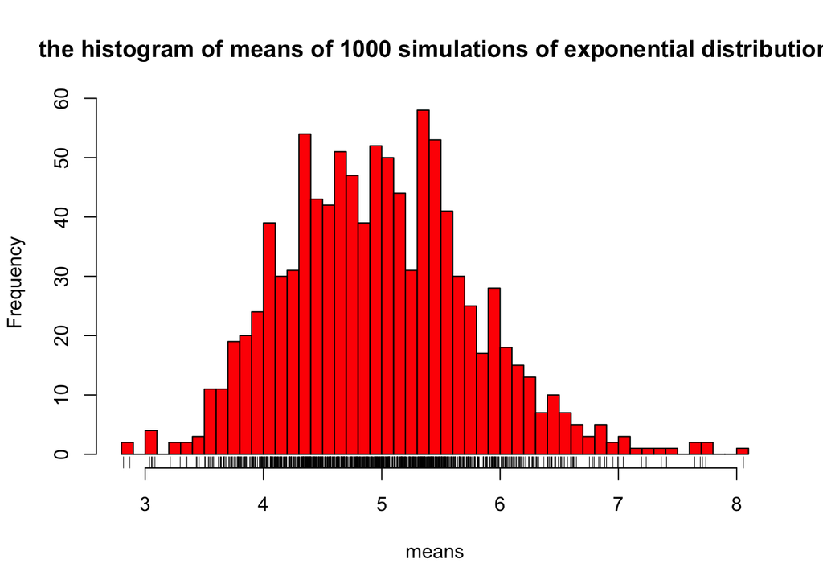

```r
means <- NULL
for (i in 1:sim) means <- c(means, mean(rexp(n,lamb)))
hist(means, col="red", main = "the histogram of means of 1000 simulations of exponential distribution", breaks = 50)
rug(means)
```

## Mean of Simulations vs. Theoretical Mean

In theory, the mean of exponential distribution is 1/lambda. Our lambda is 0.2, thus theoretical means in 5. Lets calculate mean for the simulations.

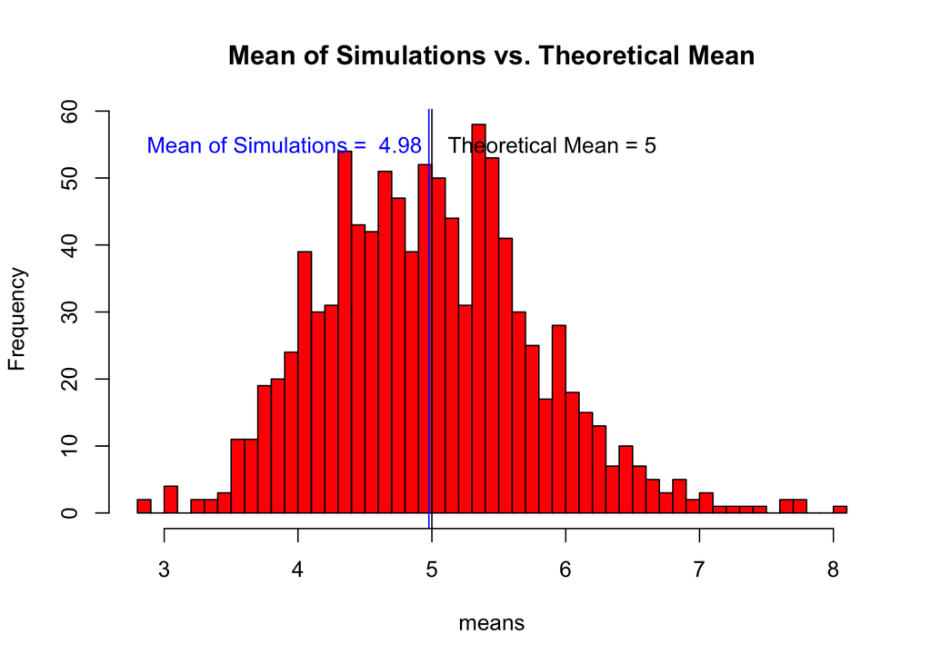

```r
hist(means, col="red", main="Mean of Simulations vs. Theoretical Mean", breaks=50)
abline(v=mean(means), lwd="1", col="blue")
abline(v=5, lwd="1", col="black")
text(3.9, 55, paste("Mean of Simulations = ", round(mean(means),2)), col="blue")
text(5.9, 55,  "Theoretical Mean = 5", col="black")
```

## Variance of Simulations vs. Theoretical Variance

In theory, the variance of exponential distribution is (1/lambda)^2/n. Lets calculate variance of simulation

```r
varsim <- var(means)
varsim
```

```
## [1] 0.6246633
```

lets calculate theoretical variance

```r
varthe <- (1/lamb)^2/n
varthe
```

```
## [1] 0.625
```

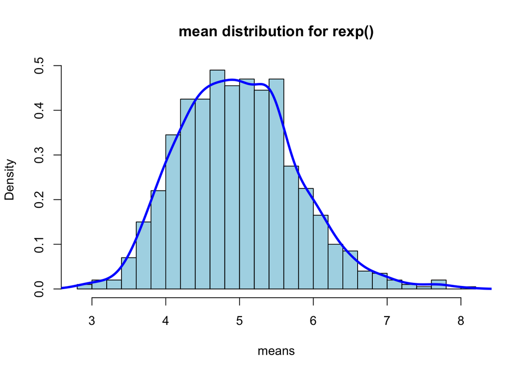

```r
hist(means, prob=TRUE, col="lightblue", main="mean distribution for rexp()", breaks=20)
lines(density(means), lwd=3, col="blue")
```